# AI sire inter-region variance

Harly Durbin

# Setup

```r
animal_regions <-
  readr::read_rds(here::here("data/derived_data/import_regions/animal_regions.rds"))
```

```r
reg_region <-
  readr::read_rds(here::here("data/derived_data/import_regions/reg_region.rds"))
```

## 1. Tally number of calves per region for each unique sire

```r
sire_tally <-
  animal_regions %>%
  group_by(sire_reg, region) %>%
  # For each sire/region combination,
  # summarize number of calves, number of CGs, mean WW
  summarise(n = n(),
            n_cg = n_distinct(cg_new),
            mean_ww = mean(weight),
            median_ww = median(weight)) %>%
  ungroup() %>%
  # Discard rows where sire has only one CG in the region
  filter(n_cg > 1) %>%
  # Discard rows where sire has fewer than 50 calves in the region
  filter(n >= 50)
```

```r
sire_pair <-
  arrangements::permutations(x = c(1:9), k = 2) %>%
  as_tibble() %>%
  filter(V1 != V2) %>%
  # Add column of median weight for first region
  left_join(sire_tally %>%
              select(sire_reg,
                     region,
                     median_v1 = median_ww),
            by = c("V1" = "region")) %>%
  # Add column of median weight for second region
  left_join(sire_tally %>%
              select(sire_reg,
                     region,
                     median_v2 = median_ww),
            by = c("V2" = "region", "sire_reg" = "sire_reg")) %>%
  select(sire_reg, everything()) %>%
  # Retain only rows with median_weight in both comparison regions
  filter_at(vars(contains("median")), all_vars(!is.na(.))) %>%
  # Calculate the difference between medians
  mutate(change = median_v1 - median_v2)
```

- Summarize number of calves in each region by each sire, number of contemporary groups in each region with calf by each sire, mean weaning weight of calves in each region by each sire
- Remove region/sire combinations with only one unique contemporary group
- Remove region/sire combinations with fewer than 50 calves
- **Number of passing sires = 1,248**

```r
baseline_change <-
  sire_pair %>%
  select(sire_reg, V1, median_v1) %>%
  distinct() %>%
  left_join(animal_regions %>%
              group_by(sire_reg) %>%
              summarise(median_overall = median(weight)) %>%
              ungroup()) %>%
  mutate(change = median_v1 - median_overall)
```

# Basic data summary

## Number of regions passing criteria per sire. What percentage of sires have 2-7 regions?

```r
sire_pair %>%
  select(sire_reg, V1, V2) %>%
  tidyr::pivot_longer(cols = c("V1", "V2")) %>%
  select(-name) %>%
  distinct() %>%
  group_by(sire_reg) %>%
  summarise(n_regions = n_distinct(value)) %>%
  ungroup() %>%
  arrange(desc(n_regions)) %>%
  group_by(n_regions) %>%
  summarise(n_sires = n_distinct(sire_reg)) %>%
  ungroup() %>%
  mutate(percent = n_sires/sum(n_sires))
```

| n_regions | n_sires | percent |
| --- | --- | --- |
| 2 | 525 | 0.42067308 |
| 3 | 205 | 0.16426282 |
| 4 | 152 | 0.12179487 |
| 5 | 112 | 0.08974359 |
| 6 | 89 | 0.07131410 |
| 7 | 165 | 0.13221154 |

- **Median number of passing regions per sire is 3**

# Comparing sire performance against its own baseline

## How many sires with region where calves are at least 20 kg lighter than the overall median weight of their calves?

```r
baseline_change %>%
  filter(change < -20) %>%
  n_distinct(.[["sire_reg"]]) %>%
  scales::comma()
```

```
## [1] "138"
```

## Which regions most often fall far below sire baseline?

```r
baseline_change %>%
  filter(change < -20) %>%
  group_by(V1) %>%
  tally() %>%
  rename(Region = V1) %>%
  arrange(desc(n))
```

| Region | n |
| --- | --- |
| 8 | 60 |
| 2 | 35 |
| 5 | 12 |
| 9 | 10 |
| 1 | 8 |
| 7 | 8 |
| 3 | 5 |

```r
baseline_change %>%
  summarise(max(median_v1),
            max(median_overall),
            min(median_v1),
            min(median_overall))
```

[output not shown]

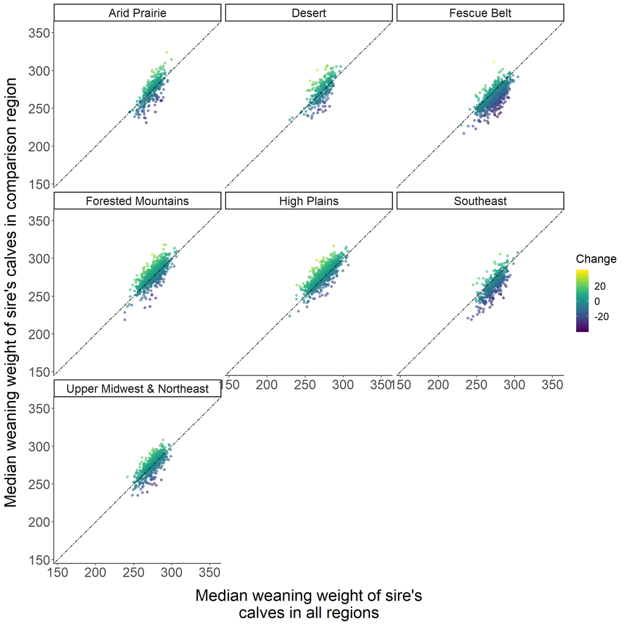

```r
baseline_change  %>%
  left_join(region_key %>%
              select(V1 = num,
                     desc)) %>%
  ggplot(aes(x = median_overall,
             y = median_v1)) +
  geom_point(aes(color = change),
             alpha = 0.6) +
  lims(x = c(155, 355),
       y = c(155, 355)) +
  geom_abline(slope = 1,
              linetype = "twodash") +
  viridis::scale_color_viridis(direction = 1) +
  theme_classic() +
  theme(legend.title = element_text(size = 16),
        legend.text = element_text(size = 14),
        axis.title = element_text(size = 22),
        axis.title.y = element_text(margin = margin(t = 0,
                                                    r = 13,
                                                    b = 0,
                                                    l = 0)),
        axis.title.x = element_text(margin = margin(t = 13,
                                                    r = 0,
                                                    b = 0,
                                                    l = 0)),
        axis.text = element_text(size = 18),
        strip.text = element_text(size = 16)) +
  facet_wrap(~desc, nrow = 3) +
  labs(x = "Median weaning weight of sire's\ncalves in all regions",
       y = "Median weaning weight of sire's calves in comparison region",
       title = NULL,
       color = "Change",
       fill = "Count")
```

# Inter-region spread

## What is the distribution of across-region spread?

```r
ir_spread <-
  baseline_change %>%
  group_by(sire_reg) %>%
  summarise(spread = max(median_v1)-min(median_v1)) %>%
  ungroup() %>%
  summarise(`Median spread` = median(spread),
            `Min. spread` = min(spread),
            `Max. spread` = max(spread),
            `SD spread` = sd(spread))
```

```r
ir_med <-
  ir_spread %>%
  pull(`Median spread`)
```

```r
ir_sd <-
  ir_spread %>%
  pull(`SD spread`)
```

```r
ir_spread
```

| Median spread | Min. spread | Max. spread | SD spread |
| --- | --- | --- | --- |
| 17.9169 | 0 | 60.32779 | 10.89403 |

## How many sires with spread greater than 3 SD above the median?

```r
baseline_change %>%
  group_by(sire_reg) %>%
  summarise(spread = max(median_v1)-min(median_v1)) %>%
  ungroup() %>%
  filter(spread >= ir_med+(ir_sd*3)) %>%
  arrange(desc(spread))
```

| sire_reg | spread |
| --- | --- |
| AAA12217765 | 60.32779 |
| AAA13556245 | 59.87420 |
| AAA14251765 | 58.05983 |
| AAA17923520 | 54.43109 |
| AAA16147094 | 52.16313 |

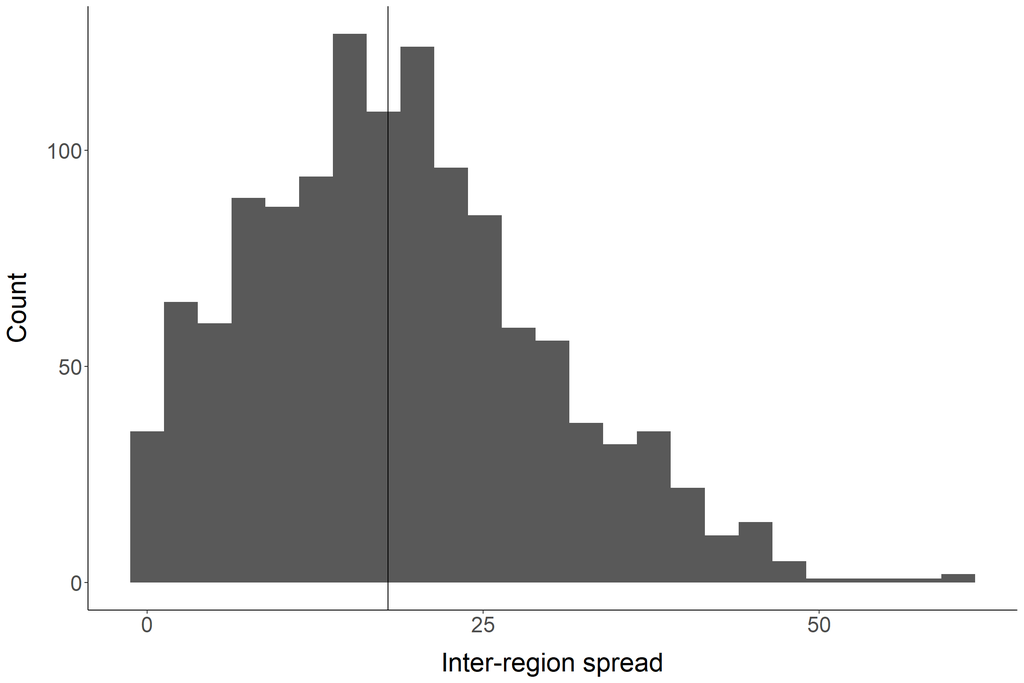

```r
baseline_change %>%
  group_by(sire_reg) %>%
  summarise(spread = max(median_v1)-min(median_v1)) %>%
  arrange(desc(spread)) %>%
  ggplot(aes(x = spread)) +
  geom_histogram(bins = 25) +  theme_classic() +
  theme(axis.title = element_text(size = 22),
        axis.title.y = element_text(margin = margin(t = 0,
                                                    r = 13,
                                                    b = 0,
                                                    l = 0)),
        axis.title.x = element_text(margin = margin(t = 13,
                                                    r = 0,
                                                    b = 0,
                                                    l = 0)),
        axis.text = element_text(size = 18)) +
  geom_vline(aes(xintercept = median(spread))) +
  scale_x_continuous(breaks = seq(from = 0, to = 300, by = 25)) +
  labs(x = "Inter-region spread",
       y = "Count",
       title = NULL)
```

# Compare sire performance in High Plains against performance in every other region

- **1,172 sires pass criteria in the High Plains**

```r
# Recreate `baseline_change` using High Plains as the "baseline"
hp_change <-
  sire_pair %>%
  filter(V1 == 3)
```

## How many sires with region where calves are at least 20 kg lighter than the overall median weight of their calves in the High Plains?

```r
hp_change %>%
  filter(change > 20) %>%
  n_distinct(.[["sire_reg"]]) %>%
  scales::comma()
```

```
## [1] "357"
```

## Which regions most often fall far below the High Plains baseline?

```r
hp_change %>%
  filter(change > 20) %>%
  group_by(V2) %>%
  tally() %>%
  rename(Region = V2) %>%
  arrange(desc(n))
```

| Region | n |
| --- | --- |
| 8 | 176 |
| 2 | 84 |
| 7 | 34 |
| 5 | 25 |
| 9 | 23 |
| 1 | 15 |

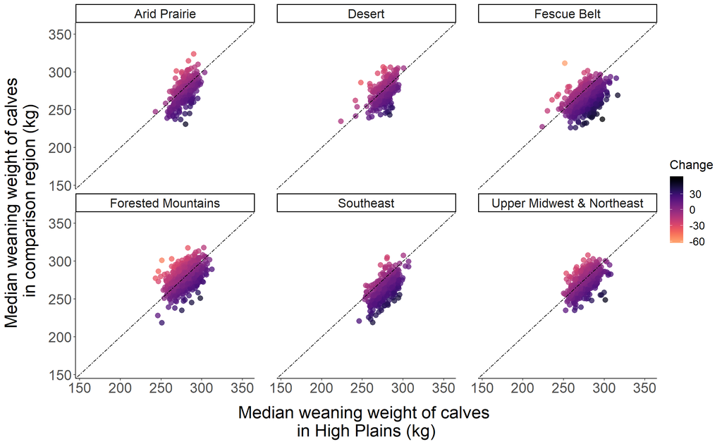

```r
sire_pair %>%
  filter(V1 == 3) %>%
  left_join(region_key %>%
              select(V1 = num,
                     desc_v1 = desc)) %>%
  left_join(region_key %>%
              select(V2 = num,
                     desc_v2 = desc)) %>%
  ggplot(aes(x = median_v1,
             y = median_v2)) +
  geom_point(aes(color = change),
             size = 3,
             alpha = 0.75) +
  lims(x = c(155, 355),
       y = c(155, 355)) +
  viridis::scale_color_viridis(option = "magma", direction = -1, end = 0.8) +
  geom_abline(slope = 1,
              linetype = "twodash") +
  theme_classic() +
  theme(legend.title = element_text(size = 16),
        legend.text = element_text(size = 14),
        axis.title = element_text(size = 22),
        axis.title.y = element_text(margin = margin(t = 0,
                                                    r = 13,
                                                    b = 0,
                                                    l = 0)),
        axis.title.x = element_text(margin = margin(t = 13,
                                                    r = 0,
                                                    b = 0,
                                                    l = 0)),
        axis.text = element_text(size = 18),
        strip.text = element_text(size = 16),
        panel.spacing.x = unit(2, "lines")) +
  facet_wrap(~desc_v2) +
  labs(y = glue("Median weaning weight of calves \n in comparison region (kg)"),
       x = glue("Median weaning weight of calves \n in High Plains (kg)"),
       title = NULL,
       color = "Change")
```

```r
ggsave(
  here::here("figures/progeny_variance/ww.sire_var.3vall_point.png"),
  width = 13,
  height = 8
)
```